# Proportion, histogram, mean, standard deviation, common distributions

Chad Worley

9/20/2021

# Proportion, binary data

When you have binary data, the proportion of success is the number of successes divided by the sample size.

$$\hat{p} = \frac{n_\text{s}}{n}$$

### Example

$$\mathbf{x} = 0, 1, 0, 1, 1, 0, 0, 1$$

```r
x = c(0,1,0,1,1,0,0,1)
n = length(x)
ns = sum(x)
phat = ns/n
data.frame(n,ns,phat)
```

```
##   n ns phat
## 1 8  4  0.5
```

$$n = 8$$
$$n_\text{s} = 4$$
$$\hat{p} = \frac{4}{8} = 0.5$$

# Proportion, discrete or continuous data

If you have discrete or continuous data, you can determine the proportion of measurements within an interval.

$$\text{prop}[\cdots] = \frac{\#[\cdots]}{n}$$
where $\cdots$ will describe an interval.

### Example

Determine the proportion of measurements that are greater than 10.5.

$$\mathbf{x} = 10, 16, 29, 1, 3, 30, 25, 4, 4, 5$$

```r
x = c(10,16,29,1,3,30,25,4,4,5)
n = length(x)
ns = sum(x>10.5)
phat = ns/n
data.frame(n,ns,phat)
```

```
##    n ns phat
## 1 10  4  0.4
```

$$n = 10$$
$$\#[x>10.5] = n_s = 4$$
$$\text{prop}[x>10.5] = \frac{\#[x>10.5]}{n} = \frac{4}{10} = 0.4$$

# Proportion (within interval) from histogram

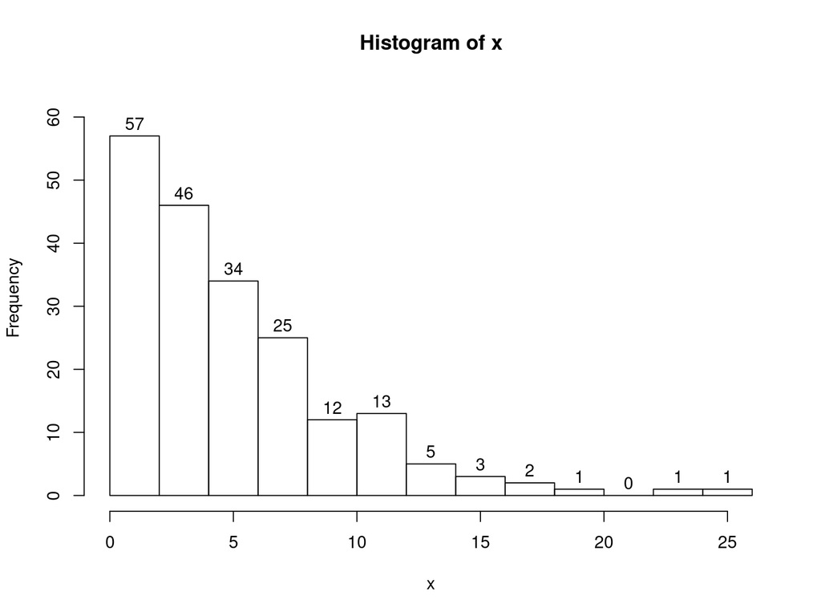

- Let’s assume $X$ is a continuous random variable, such that no measurements sit exactly on the breaks.
  - Note: it is helpful to determine the width of bars. In this case, we see there are 5 barwidths between 0 and 10. $10/5=2$, so the barwidth is equal to 2.
- How many measurements are less than 8?
  - We add the appropriate frequencies. $57+46+34+25 = 162$
    $$\#[x<8] = 162$$
  - notice we do NOT count how many bars have frequencies less than 8!
- What proportion of the measurements are less than 8?
  - We need to know the sample size. $57+46+34+25+12+13+5+3+2+1+1+1=200$
  - We divide the count by the sample size.
    $$\text{prop}[x<8] = \frac{162}{200} = 0.81$$

# Sample mean (average)

The sample mean is found by summing the measurements and dividing the sum by the sampe size.
$$\bar{x} = \frac{\sum x}{n}$$
In more technical situations, you may see more decorations to specify more precisely.

$$\bar{x} = \cfrac{\sum\limits_{i=1}^nx_i}{n}$$
Notice, with binary data, the sample mean is the sample proportion. (The sum of binary data equals the count of successes.)

# Example of finding mean

### Problem

$$\mathbf{x} = 1, 3, 2, 10, 6, 0, 5, 1, 0$$
- Calculate the sample mean $\bar{x}$.

### Solution

$$\bar{x} = \frac{\sum x}{n} = \frac{1+3+2+10+6+0+5+1+0}{9} = \frac{28}{9} = 3.1111$$

```r
x = c(1,3,2,10,6,0,5,1,0)
xbar = mean(x)
print(xbar)
```

```
## [1] 3.111111
```

$$\bar{x}=3.1111$$

# The mean is the center of mass

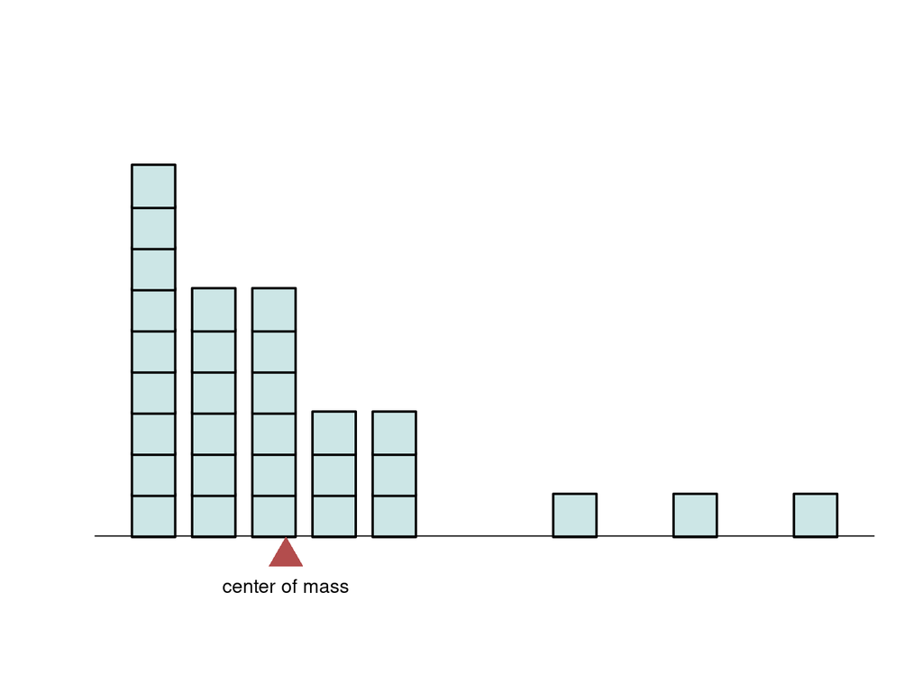

- More boxes on the left
- Boxes farther away on the right
- The platform would balance on the center of mass

# Median

- The median is another measure of center.
- To determine the median, first sort the data.
- Also, determine $n$, the sample size.
- If $n$ is odd (not a multiple of 2):
  - Find the sorted datum with index = $\frac{n+1}{2}$
- If $n$ is even (a multiple of 2):
  - Find the MEAN of sorted data with indices $\frac{n}{2}$ and $\frac{n+2}{2}$.

### Example 1

#### Problem

$$x=494, 506, 496, 496, 492, 499, 499, 497, 500, 502, 497$$
Find the median of $x$. (Find $\text{median}(x)$)

#### Solution

- First, sort the data.
  $$\text{sort}(x) = 492, 494, 496, 496, 497, 497, 499, 499, 500, 502, 506$$
- Determine $n$.
  $$n = 11$$
- Since $n$ is **odd**, we calculate the single index $\frac{n+1}{2}$.
  $$i=\frac{n+1}{2}=\frac{11+1}{2}=6$$
  We find which sorted datum in the 6th position.

$$\text{median}(x)=497$$

| $i$ | sort($x$) |
| --- | --- |
| 1 | 492 |
| 2 | 494 |
| 3 | 496 |
| 4 | 496 |
| 5 | 497 |
| 6 | 497 |
| 7 | 499 |
| 8 | 499 |
| 9 | 500 |
| 10 | 502 |
| 11 | 506 |

#### Solution using R

```r
x = c(494,506,496,496,492,499,499,497,500,502,497)
median(x)
```

```
## [1] 497
```

You could do it the long way.

```r
x = c(494,506,496,496,492,499,499,497,500,502,497)
sortedx = sort(x)
n = length(x)
if(n%%2==1){ ## this checks if n is odd
  i = (n+1)/2
  median = sortedx[i]
} else { ## the only other option is n is even
  i1 = n/2
  i2 = (n+2)/2
  median = (sortedx[i1]+sortedx[i2])/2
}
median
```

```
## [1] 497
```

# Median cont…

- The median is another measure of center.
- To determine the median, first sort the data.
- Also, determine $n$, the sample size.
- If $n$ is odd (not a multiple of 2):
  - Find the sorted datum with index = $\frac{n+1}{2}$
- If $n$ is even (a multiple of 2):
  - Find the MEAN of sorted data with indices $\frac{n}{2}$ and $\frac{n+2}{2}$.

### Example 2

#### Problem

$$x=754, 748, 762, 751, 758, 753, 759, 752, 747, 758, 742, 753, 740, 737$$
Find $\text{median}(x)$.

#### Solution

- First, sort the data.
  $$\text{sort}(x) = 737, 740, 742, 747, 748, 751, 752, 753, 753, 754, 758, 758, 759, 762$$
- Determine $n$.
  $$n = 14$$
- Since $n$ is **even**, we calculate two indices.
  $$i_1=\frac{n}{2}=\frac{14}{2}=7$$
  $$i_2=\frac{n+2}{2}=\frac{14+2}{2}=8$$
  We find the mean of the sorted data in the 7th and 8th positions.

| $i$ | sort($x$) |
| --- | --- |
| 1 | 737 |
| 2 | 740 |
| 3 | 742 |
| 4 | 747 |
| 5 | 748 |
| 6 | 751 |
| 7 | 752 |
| 8 | 753 |
| 9 | 753 |
| 10 | 754 |
| 11 | 758 |
| 12 | 758 |
| 13 | 759 |
| 14 | 762 |

#### Solution using R

```r
x = c(754,748,762,751,758,753,759,752,747,758,742,753,740,737)
median(x)
```

```
## [1] 752.5
```

You could do it the long way.

```r
x = c(754,748,762,751,758,753,759,752,747,758,742,753,740,737)
sortedx = sort(x)
n = length(x)
if(n%%2==1){ ## this checks if n is odd
  i = (n+1)/2
  median = sortedx[i]
} else { ## the only other option is n is even
  i1 = n/2
  i2 = (n+2)/2
  median = (sortedx[i1]+sortedx[i2])/2
}
median
```

```
## [1] 752.5
```

# Common Distributions

There are 6 common distribution shapes I want you to name.

- Binary
- Uniform
- Bell (Normal)
- Bimodal
- Right-skewed
- Left-skewed

# Common Distribution: Binary

- Really, I just want to remind you that binary data exists. When the data are plotted in a histogram, there are just two bars.

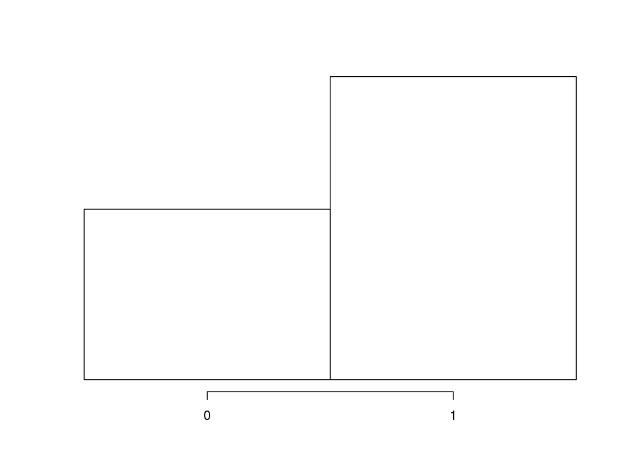

# Common Distribution: Uniform

- There is [discrete uniform](https://en.wikipedia.org/wiki/Discrete_uniform_distribution) or [continuous uniform](https://en.wikipedia.org/wiki/Continuous_uniform_distribution).
- A uniform histogram will have frequencies that are approximately equal.
- Symmetric
  - Standard dice rolled many times will produce a discrete uniform distribution.

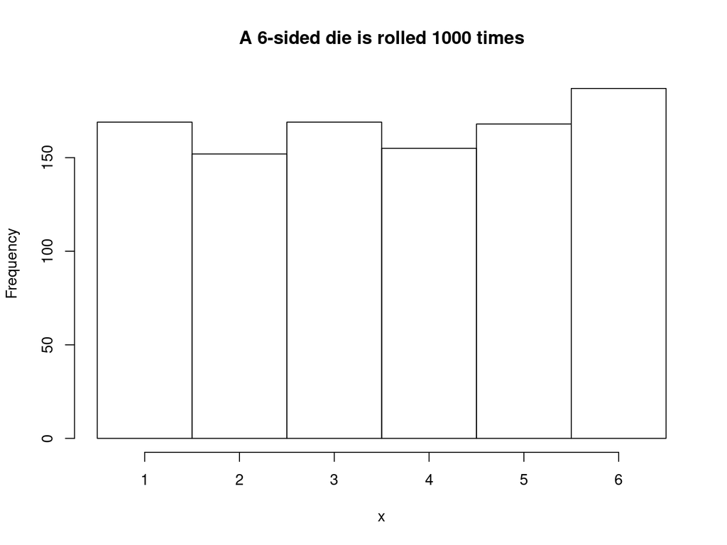

```r
x = sample(1:6,1000,T)
hist(x,breaks=seq(0.5,6.5,1),main="A 6-sided die is rolled 1000 times")
```

- The standard uniform distribution is an important continuous uniform distribution. The following spinner would produce it when spun many times.

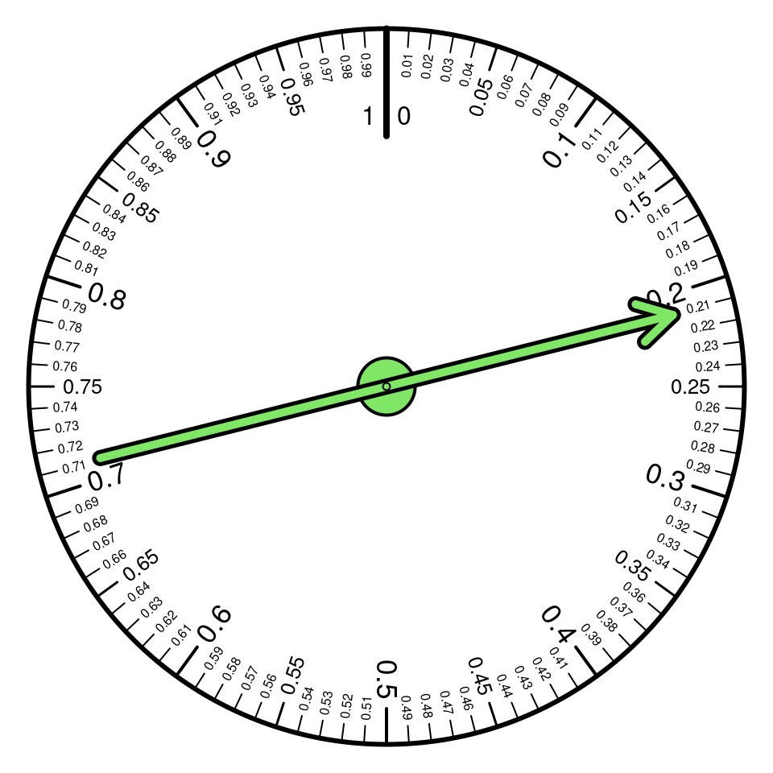

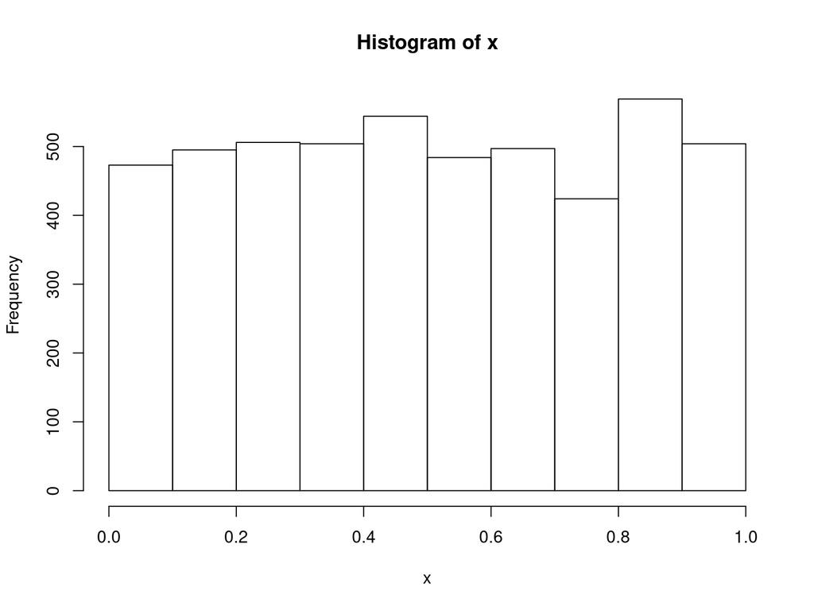

```r
x = runif(5000)
hist(x,breaks=seq(0,1,0.1))
```

# Common Distribution: Bell (Normal)

- Technically, there are multiple bell-shaped distributions. The normal distribution is just one of them.
- Symmetric
- However, we will use normal distributions A LOT.
- Sample averages (when repeatedly sampled) and sample totals (when repreatedly sampled) will tend to be approximately normal!

### Example: basketball practice

Let’s say Jessica practices freethrows by shooting 100 attempts every day and Jessica has a 80% chance of making each shot. If we track 365 days…

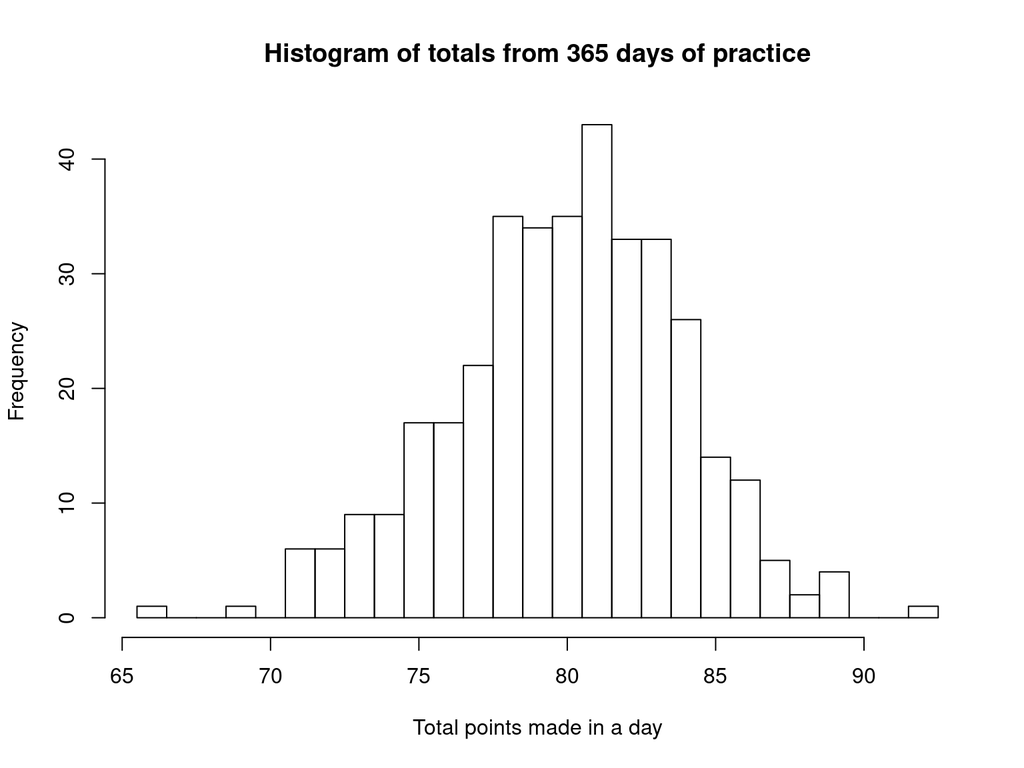

```r
x = rbinom(365,100,0.8)
hist(x,
     main = "Histogram of totals from 365 days of practice",
     xlab = "Total points made in a day",
     breaks = seq(min(x)-0.5,
                  max(x)+0.5,
                  1)
     )
```

# Common Distribution: Bimodal

- A bimodal distribution has two (approximately equally tall) hills.
- Symmetric-ish
- Not many useful, realistic examples…

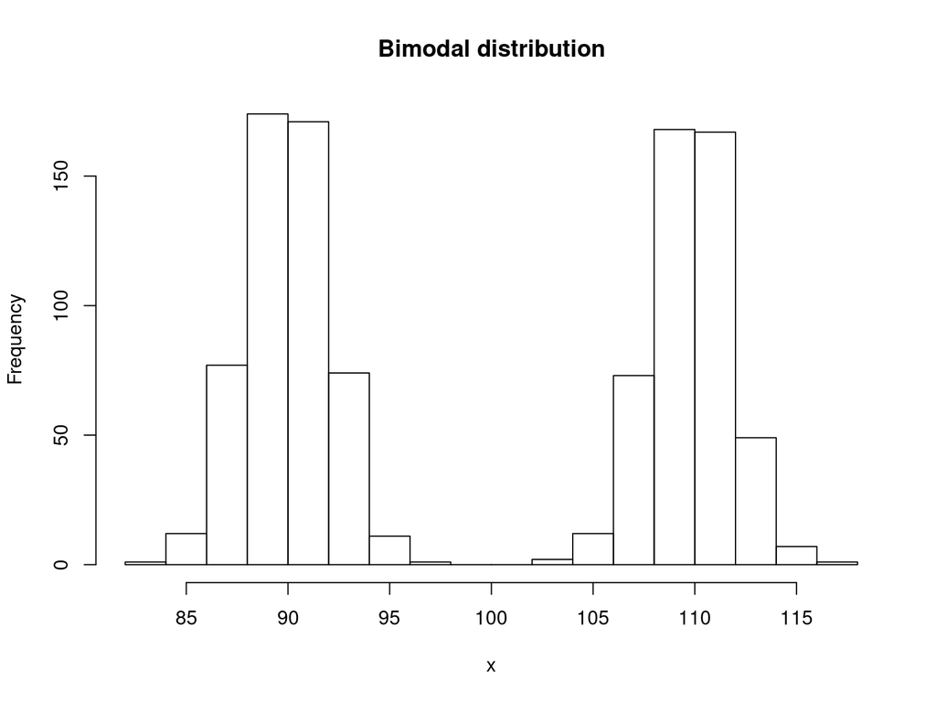

# Common Distribution: Skewed right

- Data has a right-ward tail

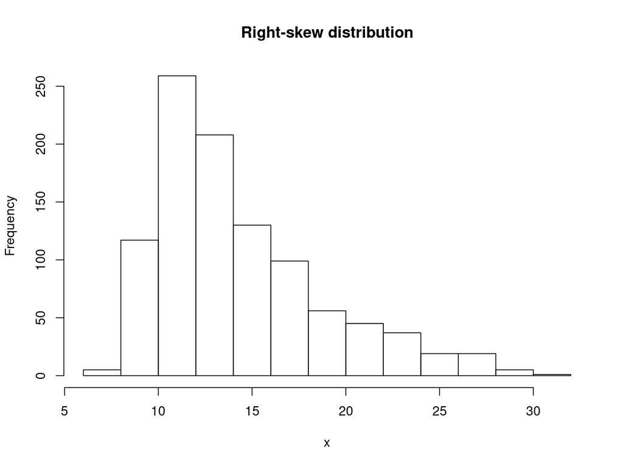

- $\text{mean} > \text{median}$

# Common Distribution: Skewed left

- Data has a left-ward tail

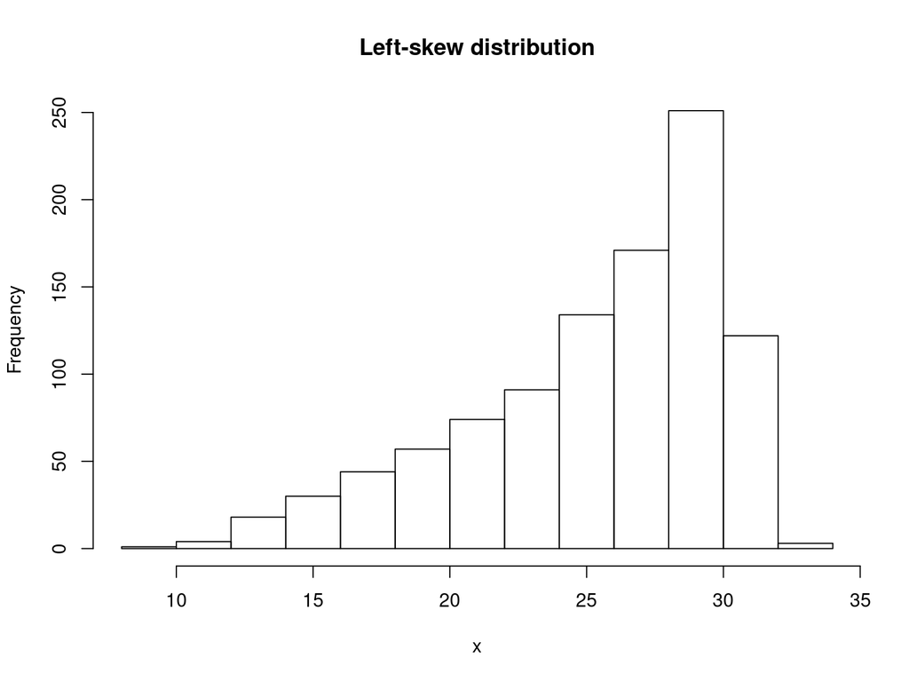

- $\text{mean} < \text{median}$

# Measures of spread

We will discuss and use various measures of spread:

- [mean absolute deviation](https://en.wikipedia.org/wiki/Average_absolute_deviation)
- range
- [variance](https://en.wikipedia.org/wiki/Variance)
- [standard deviation](https://en.wikipedia.org/wiki/Standard_deviation)
- [interquartile range (IQR)](https://en.wikipedia.org/wiki/Interquartile_range)

# Measures of spread: mean of absolute deviations

A simple measure of spread is the average (mean) of absolute deviations from the sample mean.

$$\text{mean absolute deviation} = \frac{\sum |\mathbf{x}-\bar{x}|}{n}$$
If you prefer explicit limits…
$$\text{mean absolute deviation} = \frac{\sum\limits_{i=1}^n |x_i-\bar{x}|}{n}$$

### Example

$$x = 28, 29, 28, 21, 27, 25, 21, 29$$

Determine the mean absolute deviation.

### Solution

  | x | deviation | absolute_deviation |
  | --- | --- | --- |
  | 28 | 2 | 2 |
  | 29 | 3 | 3 |
  | 28 | 2 | 2 |
  | 21 | -5 | 5 |
  | 27 | 1 | 1 |
  | 25 | -1 | 1 |
  | 21 | -5 | 5 |
  | 29 | 3 | 3 |

- Add up the absolute deviations.
  $$\sum |\mathbf{x}-\bar{x}| = 2+3+2+5+1+1+5+3 = 22$$
- Divide the sum (of absolute deviations) by the sample size.
  $$\frac{\sum |\mathbf{x}-\bar{x}|}{n} = \frac{22}{8} = 2.75$$

### Solution using R

```r
x = c(28,29,28,21,27,25,21,29)
mean(abs(x-mean(x)))
```

```
## [1] 2.75
```

### Visualization

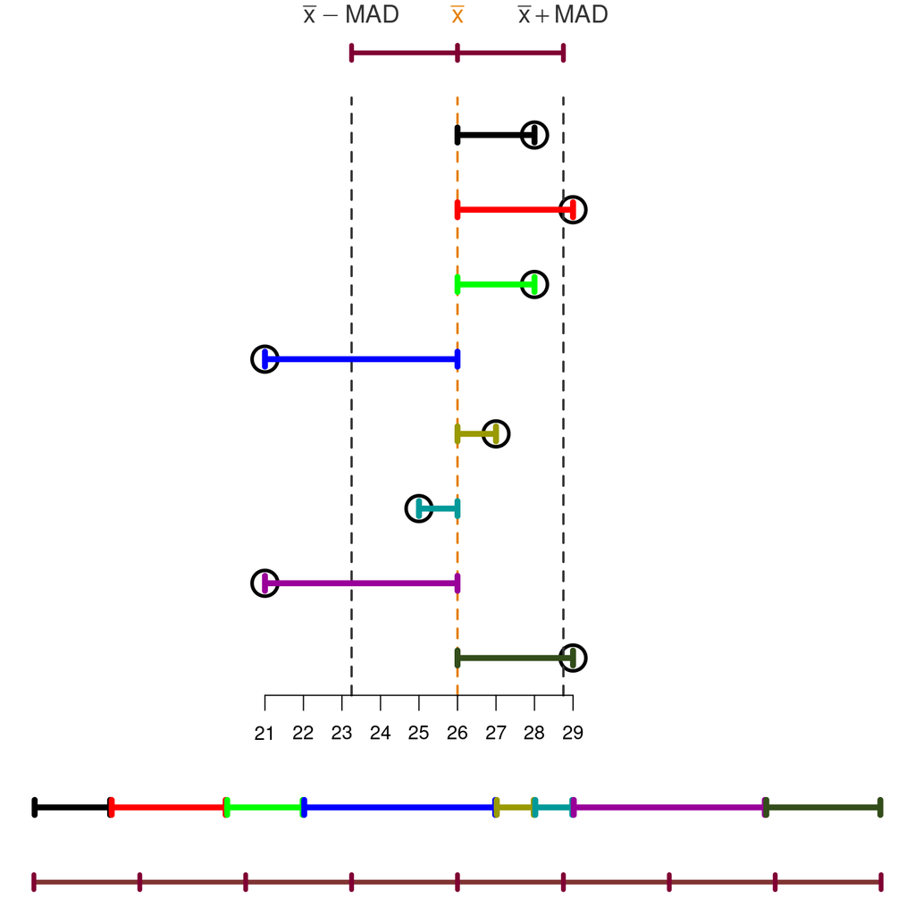

# Measures of spread: range

- The range is simply the difference between the maximum and minimum.
  $$\text{range} = \max(\mathbf{x}) - \min(\mathbf{x})$$

### Example

$$\mathbf{x}=28, 29, 28, 21, 27, 25, 21, 29$$

- Find the range of $\mathbf{x}$.

### Solution

$$29-21 = 8$$

### Notes

- The range of a sample is never larger than the range of the population.
- The range of a sample is often smaller than the range of the population.
- We say sample range is a biased estimator of population range.

# Measures of spread: variance

- variance without [Bessel correction](https://en.wikipedia.org/wiki/Bessel%27s_correction)
  $$\text{var(x)} = \frac{\sum(\mathbf{x}-\bar{x})^2}{n}$$
- variance with [Bessel correction](https://en.wikipedia.org/wiki/Bessel%27s_correction)
  $$\text{var(x)} = \frac{\sum(\mathbf{x}-\bar{x})^2}{n-1}$$
- The Bessel correction makes an unbiased estimator.

# Measures of spread: standard deviation

- sample standard deviation without [Bessel correction](https://en.wikipedia.org/wiki/Bessel%27s_correction)
  $$s_n = \sqrt{\frac{\sum(\mathbf{x}-\bar{x})^2}{n}}$$
- sample standard deviation with [Bessel correction](https://en.wikipedia.org/wiki/Bessel%27s_correction)
  $$s = \sqrt{\frac{\sum(\mathbf{x}-\bar{x})^2}{n-1}}$$
- almost always you will use Bessel correction when you have a sample